# PEC 1

Minería de datos

Autor: Gerard-Josep Alcalde Gascón

# Ejercicio 1

Propon un proyecto completo de minería de datos. La organización de la respuesta tiene que coincidir con las fases típicas del ciclo de vida de un proyecto de minería de datos. *No hay que hacer las tareas de cada fase*. Para cada fase indica cuál es el objetivo de la fase y el producto que se obtendrá. Utiliza ejemplos de qué y como podrían ser las tareas. Si hay alguna característica que hace diferente el ciclo de vida de un proyecto de minería respecto a otros proyectos indícalo.

## Introducción

Según [1] las fases de un proyecto de minería de datos son:

1. Definición de la tarea de minería de datos
2. Selección de datos
3. Preparación de datos
4. Minería de datos
5. Evaluación e interpretación del modelo
6. Integración

En este ejercicio se van a tratar estos apartados desde un punto de vista teorico con el apoyo de un dataset sobre los datos de ventas de viviendas en Melbourne.

## Presentación del proyecto

El mercado inmobiliario se caracteriza por vender propiedades que suelen ser singulares, además de disponer de un mercado de segunda mano que es muy difícil encontrar en otros sectores. Estas características hacen que evaluar el precio apropiado de compra o venta de un piso sea una tarea muy compleja.

Aprovechando la recogida de información de la venta de viviendas en los últimos años podemos hacernos con un dataset que contenga información sobre las viviendas que se han vendido y sus características y, aprovechando las posibilidades de la minería de datos, poder estimar el precio de venta apropiado para una vivienda.

## Definición de la tarea de minería de datos

En esta primera fase se tratará de determinar el objetivo del proceso de minería de datos. Este proceso se puede agrupar en 5 grupos distintos [1]:

1. Encontrar similitudes y agrupar objetos parecidos
2. Clasificar objetos
3. Predecir
4. Describir
5. Explicar

En el ejemplo de este ejercicio, el objetivo sería una predicción, ya que buscamos generar un modelo que estime el precio de venta de una vivienda, basándose en los datos presentes.

Por otro lado, debemos determinar como vamos a estimar el grado de cumplimiento del objetivo. Para ello lo que haríamos con este dataset sería separar los datos en un grupo de entreno y uno de evaluación, generaríamos el modelo a partir del grupo de entreno y posteriormente lo evaluaríamos con el de evaluación. Finalmente estableceríamos un grado de confianza en estos resultados que, dependiendo del tipo de datos que analicemos podría ser mayor o menor. En este caso, al tratarse de datos inmobiliarios podríamos optar por una precisión del 90%, la cual no es muy elevada.

También tenemos que entender el contexto y como se podrían aplicar los resultados obtenidos. Es importante tener en cuenta que el mercado inmobiliario va evolucionando con los años, quizás un barrio que antiguamente no era popular ahora si lo es, o simplemente la evolución de los precios con los años puede ser muy importante (incremento del valor del dinero, inflación, crisis, etc.). Por estos motivos, los datos a analizar deben ser lo más actuales posibles (con una antigüedad probablemente no superior a 2-3 años, aunque esto sería recomendable preguntarlo a especialistas en el campo) y además el modelo obtenido no se podrá utilizar durante un período de tiempo largo, sino que se tendrán que actualizar los datos y renovar el modelo. Teniendo en cuenta estos factores, el modelo obtenido sería de gran utilidad para las empresas del sector inmobiliario además de para las personas interesadas en comprar o vender una vivienda en la región de estudio.

Finalmente, también es importante evaluar si nuestro objetivo puede ser respondido con los datos presentes. El dataset del que disponemos nos informa de características de las viviendas, entre ellas el barrio, precio de venta, estilo de vivienda o tamaño entre otros. Por ello, podemos determinar que basándonos en los datos de los que disponemos se puede responder al objetivo de este proyecto.

## Selección de datos

En la fase de selección de datos se trata de conseguir los datos que necesitaremos para cumplir los objetivos del proyecto. Estos datos pueden obtenerse desde un data warehouse en la situación ideal o sino habrá que obtenerlos por otros medios.

El objetivo de esta fase será obtener unos datos de suficiente calidad como para porporcionar una base sólida para cumplir los objetivos del proyecto. Como resultado de esta fase se obtiene un fichero (o varios) con los datos para trabajar en el proyecto.

## Preparación de los datos

Esta fase suele ser la que requiere mayor tiempo dentro del proyecto de minería de datos y consiste en tratar los datos de partida para poder trabajar con ellos de una manera adecuada obteniendo una solución con la suficiente calidad. En esta fase se realizará una limpieza de los datos, posteriormente se transformarán y finalmente en caso de que fuese necesario se reduciría la dimensionalidad.

Primero de todo en esta fase tendremos que verificar distintos aspectos de los datos [1]:

1. Calidad de los datos: No contengan errores, redundancias u otros errores, asegurando así la calidad del modelo resultante.
2. Tener los datos necesarios: Puede ser necesario añadir nuevos datos, obtener de nuevos o combinar algunos de ellos.
3. Forma adecuada de los datos: Hay que convertir los datos que tenemos a las necesidades de los modelos, discretización, cambio de tipo de datos, etc.

En nuestro ejemplo empezaremos por cargar los datos y estudiarlos:

```python
import pandas as pd
```

```python
df = pd.read_csv("Melbourne_housing_FULL.csv")
df.head()
```

|  | Suburb | Address | Rooms | Type | Price | Method | SellerG | Date | Distance | Postcode | ... | Bathroom | Car | Landsize | BuildingArea | YearBuilt | CouncilArea | Lattitude | Longtitude | Regionname | Propertycount |
| --- | --- | --- | --- | --- | --- | --- | --- | --- | --- | --- | --- | --- | --- | --- | --- | --- | --- | --- | --- | --- | --- |
| 0 | Abbotsford | 68 Studley St | 2 | h | NaN | SS | Jellis | 3/09/2016 | 2.5 | 3067.0 | ... | 1.0 | 1.0 | 126.0 | NaN | NaN | Yarra City Council | -37.8014 | 144.9958 | Northern Metropolitan | 4019.0 |
| 1 | Abbotsford | 85 Turner St | 2 | h | 1480000.0 | S | Biggin | 3/12/2016 | 2.5 | 3067.0 | ... | 1.0 | 1.0 | 202.0 | NaN | NaN | Yarra City Council | -37.7996 | 144.9984 | Northern Metropolitan | 4019.0 |
| 2 | Abbotsford | 25 Bloomburg St | 2 | h | 1035000.0 | S | Biggin | 4/02/2016 | 2.5 | 3067.0 | ... | 1.0 | 0.0 | 156.0 | 79.0 | 1900.0 | Yarra City Council | -37.8079 | 144.9934 | Northern Metropolitan | 4019.0 |
| 3 | Abbotsford | 18/659 Victoria St | 3 | u | NaN | VB | Rounds | 4/02/2016 | 2.5 | 3067.0 | ... | 2.0 | 1.0 | 0.0 | NaN | NaN | Yarra City Council | -37.8114 | 145.0116 | Northern Metropolitan | 4019.0 |
| 4 | Abbotsford | 5 Charles St | 3 | h | 1465000.0 | SP | Biggin | 4/03/2017 | 2.5 | 3067.0 | ... | 2.0 | 0.0 | 134.0 | 150.0 | 1900.0 | Yarra City Council | -37.8093 | 144.9944 | Northern Metropolitan | 4019.0 |

5 rows × 21 columns

```python
df.shape
```

```
(34857, 21)
```

En estos se debería analizar los distintos tipos de datos que tenemos, comprobar que el tipo de datos correspondan con los títulos de las columnas, analizar que atributos pueden ser irrelevantes, etc.

La limpieza de datos consistirá en una correcta gestión de los datos vacíos, eliminar datos redundantes, gestionar datos incorrectos, evitar errores de trasncripción, gestionar los datos envejecidos, etc.

En el ejemplo de la inmobiliaría para limpiar los datos empezaríamos por analizar cuantos datos vacíos tenemos de cada variable:

```python
df.isna().sum()
```

```
Suburb               0
Address              0
Rooms                0
Type                 0
Price             7610
Method               0
SellerG              0
Date                 0
Distance             1
Postcode             1
Bedroom2          8217
Bathroom          8226
Car               8728
Landsize         11810
BuildingArea     21115
YearBuilt        19306
CouncilArea          3
Lattitude         7976
Longtitude        7976
Regionname           3
Propertycount        3
dtype: int64
```

Una vez obtenidos cuantos valores vacíos tenemos hay que determinar como gestionarlos. Generalmente una buena práctica consiste en:

- <50% vacíos: Se reemplazan por la media, la mediana, por cero u otras
- 50-95% vacíos: No se rellenan
- >95%: Se descartan el atributo

En este caso atributos como Price, Bedroom2 o Car, entre otros, se podrían reemplazar mientras que otros como BuildingArea o YearBuilt no se deberían rellenar.

A la hora de reemplazar algunos datos hay que vigilar como se hace. Por ejemplo reemplazar la variable price por la media de esta variable podría dar lugar a que viviendas con un precio de venta muy elevado o muy bajo pasen a tener el precio medio de todas las viviendas vendidas, para evitar esto podríamos utilizar una variable que supuestamente este correlacionada con el precio para agrupar las observaciones y poner el precio medio de algún grupo. Un caso que se podría emplear sería el número de habitaciones o el número de habitaciones y el barrio, entendiendo que dos viviendas de un mismo barrio y el mismo número de habitaciones deberían tener un precio similar.

A continuación podríamos trabajar con la eliminación de datos repetidos:

```python
df.duplicated().sum()
```

```
1
```

Vemos que hay exclusivamente una fila duplicada, por lo tanto podríamos eliminar la observación duplicada.

Para gestionar los datos incorrectos deberíamos mostrar un resumen de los datos que tenemos en el dataframe:

```python
df.describe()
```

|  | Rooms | Price | Distance | Postcode | Bedroom2 | Bathroom | Car | Landsize | BuildingArea | YearBuilt | Lattitude | Longtitude | Propertycount |
| --- | --- | --- | --- | --- | --- | --- | --- | --- | --- | --- | --- | --- | --- |
| count | 34857.000000 | 2.724700e+04 | 34856.000000 | 34856.000000 | 26640.000000 | 26631.000000 | 26129.000000 | 23047.000000 | 13742.00000 | 15551.000000 | 26881.000000 | 26881.000000 | 34854.000000 |
| mean | 3.031012 | 1.050173e+06 | 11.184929 | 3116.062859 | 3.084647 | 1.624798 | 1.728845 | 593.598993 | 160.25640 | 1965.289885 | -37.810634 | 145.001851 | 7572.888306 |
| std | 0.969933 | 6.414671e+05 | 6.788892 | 109.023903 | 0.980690 | 0.724212 | 1.010771 | 3398.841946 | 401.26706 | 37.328178 | 0.090279 | 0.120169 | 4428.090313 |
| min | 1.000000 | 8.500000e+04 | 0.000000 | 3000.000000 | 0.000000 | 0.000000 | 0.000000 | 0.000000 | 0.00000 | 1196.000000 | -38.190430 | 144.423790 | 83.000000 |
| 25% | 2.000000 | 6.350000e+05 | 6.400000 | 3051.000000 | 2.000000 | 1.000000 | 1.000000 | 224.000000 | 102.00000 | 1940.000000 | -37.862950 | 144.933500 | 4385.000000 |
| 50% | 3.000000 | 8.700000e+05 | 10.300000 | 3103.000000 | 3.000000 | 2.000000 | 2.000000 | 521.000000 | 136.00000 | 1970.000000 | -37.807600 | 145.007800 | 6763.000000 |
| 75% | 4.000000 | 1.295000e+06 | 14.000000 | 3156.000000 | 4.000000 | 2.000000 | 2.000000 | 670.000000 | 188.00000 | 2000.000000 | -37.754100 | 145.071900 | 10412.000000 |
| max | 16.000000 | 1.120000e+07 | 48.100000 | 3978.000000 | 30.000000 | 12.000000 | 26.000000 | 433014.000000 | 44515.00000 | 2106.000000 | -37.390200 | 145.526350 | 21650.000000 |

Atributo por atributo deberíamos valorar si tienen sentido los resultados obtenidos determinando cual es el rango lógico de los resultados y si hay algún valor que exceda esos valores y entonces decidir como tratarlo. Como un ejemplo vemos que el precio medio de la vivienda en Melbourne es de 1.000.000 dólares y tenemos una vivienda vendida por 85.000 dólares, esto es un 90% por debajo del precio medio, esta sería una observación que deberíamos estudiar en profundidad. En el número de habitaciones observamos que una vivienda dispone de 30 habitaciones, este sería otro dato a estudiar, ya que es posible pero no deja de ser extraño. En YearBuilt aparece una vivienda que se ha construido en 2106, lo cual debe ser un error de transcripción con el cual deberíamos tratar ya que está fuera del rango posible de este atributo.

Podría ser útil aplicar una reducción en la dimensionalidad de los datos a tratar en nuestro modelo, de esta forma mejoraríamos la velocidad del modelo, esto puede aplicarse con los atributos que no estén correlacionados con nuestro atributo objetivo o con aquellos que dificulten el modelado. Ejemplos de estos casos que encontramos en el dataset de estudio serían:

- Address: El barrio nos da una categorización de las viviendas por localización suficientemente buena, incluir la dirección exacta o una calle nos daría una categoría muy segmentada y poco útil.
- Lattitude y Longtitude: Igual que con Address.
- SellerG: A la hora de predecir el precio de venta de una vivienda de forma genérica el nombre del vendedor no será necesario, ya que es probable que no podamos disponer de ese vendedor. No obstante, si el modelo fuese de uso interno para una agencia inmobiliaria en concreto podría ser interesante obtener que vendedores han conseguido mejores precios de venta, pero esto se saldría del objetivo definido en este proyecto.

Variables continuas como BuildingArea o Landsize podrían segmentarse dentro de unas cuantas categorías por ejemplo BuildingArea se podría segmentar en [0-80], (80,120], (120,160] y (160,inf.). Dado que el tamaño exacto de la vivienda no es decisivo, sino que lo es que una vivienda este en un rango de tamaño determinado, esta segmentación simplificará este atributo y mejorará la velocidad del modelo sin afectar de forma relevante en la precisión del modelo.

Finalmente se debería realizar una normalización de ciertas variables, ya que la variable Price se encuentra en una escala muy diferente a la del número de habitaciones o al tamaño del piso. Se podrían aplicar múltiples técnicas de transformación de estos atributos, entre las más utilizadas encontraríamos la normalización (que puede ser por máximos, por diferencia, etc.).

Otros de los factores a tener en cuenta es si se esta produciendo oversampling o undersampling produciendo que el modelo solo aprendiese de clase de la que tiene más información. Esto se producirá cuando haya una determinada clase que represente una mayoría significativa sobre el conjunto de datos. Distintas técnicas como SMOTE o ADASYN tratan con este tipo de problemas.

Estas serían algunas de las formas en las que se podrían trabajar los datos para mejorar el resultado del modelo.

En este punto ya deberíamos encontrarnos con unos datos los suficientemente bien tratados como para poder iniciar el proceso de minería de datos.

### Análisis exploratorio de datos

Como paso final en el preprocesado de los datos se realiza un análisis exploratorio de los datos.

En el análisis exploratorio de datos se realizará una inspección de los datos explotando las herramientas de visualización que tenemos disponibles. En esta fase trataremos de observar el tipo de distribuciones que tenemos en nuestros datos y las correlaciones que hay entre distintos atributos.

El objetivo de esta fase será el de tratar de obtener unas conclusiones iniciales al respecto de los datos que tenemos y con ello poder preparar los datos todavía más antes de la creación del modelo.

En caso de obtener una distribución sesgada a izquierda o derecha podríamos aplicar una transformación potencial o logarítmica respectivamente para obtener magnitudes más uniformes.

Si dos variables explicativas están fuertemente correlacionadas significaría que aportan información redundante y podríamos prescindir de una de ellas.

## Minería de datos

En el proceso de minería de datos, los datos del proyecto ya se encuentran con una calidad adecuada y los atributos ya han sido filtrados. En esta fase se tratará de decidir entre los distintos métodos que hay para obtener el modelo deseado.

Lo habitual será hacer distintos modelos e iterar sobre estos hasta obtener el modelo que mejor responda a las necesidades de nuestro proyecto.

A la hora de evaluar el modelo algunos de los problemas habituales son [1]:

- Mínimos locales: El modelo que mejor responde a nuestros datos solo lo hace en comparativa con los modelos que lo comparamos.
- Overfitting: El modelo no es capaz de generalizar correctamente y es muy especifico con nuestro grupo de datos.
- Envejecimiento del modelo: El modelo no responderá correctamente a datos futuros

En nuestro ejemplo de la inmobiliaría estábamos buscando un modelo de predicción, por tanto se podría emplear un árbol de decisión o un modelo de regresión.

## Evaluación del modelo

En esta fase se busca evaluar si el modelo que hemos obtenido del proceso de minería de datos cumple con nuestro objetivo inicial.

Habitualmente se divide el dataset inicial en dos conjuntos el de entreno y el de test, no obstante, a veces se introduce un tercer conjunto, el de validación. Mientras que el grupo de test nos ha ayuda a determinar que modelo era el óptimo, este tercer grupo de validación nos ayudará a determinar si la fiabilidad del modelo es correcta.

Para los modelos predictivos se buscará determinar hasta que punto son buenos haciendo predicciones, mientras que para los modelos descriptivos evaluaremos hasta que punto se ajustan al dominio descrito.

Para nuestro modelo predictivo se podría estimar un rango en el cual consideremos que la predicción del valor de venta de la vivienda es suficientemente buena, por ejemplo (+-)5% y exigir que el 90 o 95% de las predicciones se situen en este rango.

El objetivo de esta fase será dar una conclusión final al respecto de si el modelo es útil o si se tiene que volver a iterar el proceso con el objetivo de obtener un modelo más fiable.

## Integración

El paso final de todo modelo de minería consistirá en su integración en el sistema de información en el que se esté aplicando. Este paso puede requerier una transformación del lenguaje de programación para integrarse en el sistema donde será utilizado.

En nuestro caso esto podría implicar que si el modelo se usase en una página web de venta de viviendas, que al insertar todas las características de tu vivienda, la propia web te estimase el precio de venta más adecuado para esta.

# Ejercicio 2

A partir del juego de datos disponible en el siguiente enlace https://www.kaggle.com/rdoume/beerreviews , realiza las tareas previas a la generación de un modelo de minería de datos explicadas en los módulos "El proceso de minería de datos" y "Preprocesado de los datos y gestión de características". Puedes utilizar de referencia el ejemplo del Titánic.

El proceso de trabajo será [2]:

1. Asegurarse que los datos se han registrado correctamente
2. Verificar que el rango de los datos sea aceptable
3. Gestionar los valores nulos
4. Generear gráficos para verificar de forma visual el juego de datos.
5. Análisis exploratorio

```python
import pandas as pd
import numpy as np
from matplotlib import pyplot as plt
import seaborn as sns
from math import pi
```

Cargamos los datos en brewData que contenerá el dataset de estudio y guardamos en la variable filas el número de filas del dataset.

```python
brew_df = pd.read_csv("beer_reviews.csv")
```

Mostramos las primeras filas del dataframe para observar el estilo de los datos que analizaremos posteriormente

```python
brew_df.head()
```

[output not shown]

```python
brew_df.shape
```

[output not shown]

```python
brew_df.info()
```

[output not shown]

Con la información anterior y el dataframe podemos dar una descripción de los distintos atributos y valorar si el tipo de dato almacenado en ellos parece correcto.

Las variables del sataset son:

- **brewery_id** string with the brewery identifier.
- **brewery_name** string with the brewery name.
- **review_time** int with the review date. Time in format Unix time [1] ("What is Unix time?", 2021).
- **review_overall** float in range [0, 5] with the overall score of the beer.
- **review_aroma** float in range [0, 5] with the aroma score of the beer.
- **review_appearance** float in range [0, 5] with the appearance score of the beer.
- **review_profilename** string profile name of the review user.
- **beer_style** string that catalog the beer into different beer styles, it can get more than one style.
- **review_palate** float in range [0, 5] with the palatibity score of the beer.
- **review_taste** float in range [0, 5] with the taste score of the beer.
- **beer_name** string with the beer name.
- **beer_abv** float with the alcohol percentage of the beer.
- **beer_beerid** int with the beer identifier.

De la observación del dataframe obtenemos que todas las variables parecen ser correctas y que las dos únicas variables que nos pueden generar problemas son review_time al encontrarse en formato unix [3] y beer_style al unir múltiples estilos de cerveza en una misma variable. Más adelante, cuando veamos las necesidades del estudio valoraremos como tratar con cada una de estas variables, pero beer_style parece conveniente separarla o generar una lista de estilos para poder comparar el estilo de diversas cervezas.

A continuación procedemos a sacar las estadísticas básicas de las variables.

```python
brew_df.describe()
```

|  | brewery_id | review_time | review_overall | review_aroma | review_appearance | review_palate | review_taste | beer_abv | beer_beerid |
| --- | --- | --- | --- | --- | --- | --- | --- | --- | --- |
| count | 1.586614e+06 | 1.586614e+06 | 1.586614e+06 | 1.586614e+06 | 1.586614e+06 | 1.586614e+06 | 1.586614e+06 | 1.586614e+06 | 1.586614e+06 |
| mean | 3.130099e+03 | 1.224089e+09 | 3.815581e+00 | 3.735636e+00 | 3.841642e+00 | 3.743701e+00 | 3.792860e+00 | 7.001855e+00 | 2.171279e+04 |
| std | 5.578104e+03 | 7.654427e+07 | 7.206219e-01 | 6.976167e-01 | 6.160928e-01 | 6.822184e-01 | 7.319696e-01 | 2.297935e+00 | 2.181834e+04 |
| min | 1.000000e+00 | 8.406720e+08 | 0.000000e+00 | 1.000000e+00 | 0.000000e+00 | 1.000000e+00 | 1.000000e+00 | 1.000000e-02 | 3.000000e+00 |
| 25% | 1.430000e+02 | 1.173224e+09 | 3.500000e+00 | 3.500000e+00 | 3.500000e+00 | 3.500000e+00 | 3.500000e+00 | 5.200000e+00 | 1.717000e+03 |
| 50% | 4.290000e+02 | 1.239203e+09 | 4.000000e+00 | 4.000000e+00 | 4.000000e+00 | 4.000000e+00 | 4.000000e+00 | 6.500000e+00 | 1.390600e+04 |
| 75% | 2.372000e+03 | 1.288568e+09 | 4.500000e+00 | 4.000000e+00 | 4.000000e+00 | 4.000000e+00 | 4.500000e+00 | 8.500000e+00 | 3.944100e+04 |
| max | 2.800300e+04 | 1.326285e+09 | 5.000000e+00 | 5.000000e+00 | 5.000000e+00 | 5.000000e+00 | 5.000000e+00 | 5.770000e+01 | 7.731700e+04 |

De este resumen de estadística báscia podemos sacar múltiples conclusiones. Tenemos un máximo de 28003 cervecerías distintas y 77317 cervezas distintas en el análisis, por lo que algunas cervezas se habrán probado en múltiples cervecerías y en una misma cervecería se habrán probado distintos tipos de cerveza. Además al haber más de 1,5 millones de reseñas, podremos sacar estadísticas de distintas cervecerías y de distintas cervezas. brewery_name, review_profilename, beer_style y beer_name son de tipo string y por tanto no tenemos valores estadísticos. Las variables review_overall y review_appearance parecen oscilar entre [0-5] mientras que review_aroma, review_palate y review_taste parecen oscilar entre [1-5], aunque no podemos darlo por seguro y es una información que debería proporcionarnos el proveedor de los datos, de momento continuaremos con la asumción que estas variables pertenecen al rango [0-5].

Para el atributo beer_abv valoramos el porcentaje de alcohol de la cerveza, el cual se tiene que encontrar entre 0 y 100 y efectivamente todos los valores se encuentran en este rango. No obstante, por conocimiento personal sabemos que una cerveza tiene un porcentaje de alcohol alrededor del 6-7% y puede ser extraño ese valor del 57,7% en el máximo, el cual podría ser un outlier. Tras una breve investigación por internet encontramos que hay cervezas con un porcentaje de alcohol de hasta el 70%, por ello aceptamos este valor como correcto y descartamos que se trate de un outlier.

Ahora podemos analizar el número total de valores vacíos:

```python
brew_df.isna().sum()
```

[output not shown]

La variable beer_style parece mostrar distintos estilos de cerveza y en algunas observaciones encontramos varios estilos asignados, vamos a estudiar más en profundidad esta variable. Veamos cuantos valores unicos tenemos:

```python
unique_beer_styles_list = brew_df.beer_style.unique().tolist()
print(unique_beer_styles_list)
len(unique_beer_styles_list)
```

```
['Hefeweizen', 'English Strong Ale', 'Foreign / Export Stout', 'German Pilsener', 'American Double / Imperial IPA', 'Herbed / Spiced Beer', 'Light Lager', 'Oatmeal Stout', 'American Pale Lager', 'Rauchbier', 'American Pale Ale (APA)', 'American Porter', 'Belgian Strong Dark Ale', 'American IPA', 'Am…
```

```
104
```

Tenemos un total de 104 estilos de cerveza distintos, lo cual requeriría un gran trabajo para poderlas procesar ya que no se ha descrito un atributo que indique la procedencia de estas cervezas o si son oscuras o rubias, por tanto, será complejo poder agrupar estas cervezas en un grupo con menos categorías. Para lo que si que nos puede servir esta variable es para asignar un valor del porcentaje de alcohol en los valores ausentes.

```python
#brew_df.beer_abv = brew_df.beer_abv.fillna(brew_df.beer_abv.mean())
brew_df.beer_abv = brew_df.groupby("beer_style")["beer_abv"].transform(lambda x: x.fillna(x.mean()))
brew_df.brewery_name = brew_df.brewery_name.fillna("Unknown")
brew_df.review_profilename  = brew_df.review_profilename .fillna("Unknown")
brew_df.isna().sum()
```

```
brewery_id            0
brewery_name          0
review_time           0
review_overall        0
review_aroma          0
review_appearance     0
review_profilename    0
beer_style            0
review_palate         0
review_taste          0
beer_name             0
beer_abv              0
beer_beerid           0
dtype: int64
```

Con esto ya no tenemos valores vacíos ni en texto ni en valores numéricos

Vemos que el porcentaje de alcohol (beer_abv) se encuentra en una variable continua y podría ser interesante discretizarla, se podría separar en porcentaje bajo (<5%), medio (5%-8%), alto (8%-12%) y muy alto (>12%):

```python
bins = [0, 5, 8, 12, 100]
brew_df["alcohol_level"] = pd.cut(brew_df.beer_abv, bins , labels = ["low (0-5%)", "middle (5-8%)", "high (8-12%)", "very high (>12%)"])
brew_df.head()
```

|  | brewery_id | brewery_name | review_time | review_overall | review_aroma | review_appearance | review_profilename | beer_style | review_palate | review_taste | beer_name | beer_abv | beer_beerid | alcohol_level |
| --- | --- | --- | --- | --- | --- | --- | --- | --- | --- | --- | --- | --- | --- | --- |
| 0 | 10325 | Vecchio Birraio | 1234817823 | 1.5 | 2.0 | 2.5 | stcules | Hefeweizen | 1.5 | 1.5 | Sausa Weizen | 5.0 | 47986 | low (0-5%) |
| 1 | 10325 | Vecchio Birraio | 1235915097 | 3.0 | 2.5 | 3.0 | stcules | English Strong Ale | 3.0 | 3.0 | Red Moon | 6.2 | 48213 | middle (5-8%) |
| 2 | 10325 | Vecchio Birraio | 1235916604 | 3.0 | 2.5 | 3.0 | stcules | Foreign / Export Stout | 3.0 | 3.0 | Black Horse Black Beer | 6.5 | 48215 | middle (5-8%) |
| 3 | 10325 | Vecchio Birraio | 1234725145 | 3.0 | 3.0 | 3.5 | stcules | German Pilsener | 2.5 | 3.0 | Sausa Pils | 5.0 | 47969 | low (0-5%) |
| 4 | 1075 | Caldera Brewing Company | 1293735206 | 4.0 | 4.5 | 4.0 | johnmichaelsen | American Double / Imperial IPA | 4.0 | 4.5 | Cauldron DIPA | 7.7 | 64883 | middle (5-8%) |

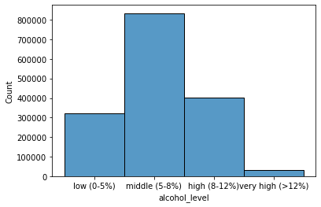

```python
sns.histplot(brew_df.alcohol_level)
plt.show()
```

Observamos como obtenemos una distribución cercana a una distribución normal donde la mayoría de los resultados se centran en el valor intermedio de alcohol y el resto principalmente se encuentran en bajo y alto, siendo solo unos pocos valores los que se encuentran en muy alto.

Dado que el porcentaje de alcohol oscila entre 0 y 100, lo podemos normalizar entre 0 y 1 y así si lo comparamos con las puntuaciones estará en una escala similar. A continuación procedemos a hacer esta normalización.

```python
brew_df["beer_abv_NM"] = brew_df.beer_abv.div(100)
brew_df.head()
```

[output not shown]

A continuación vamos a estudiar cuales son las 10 cervezas con mejor puntuación, y estudiaremos cuales son sus características. Primero de todo tenemos que encontrar cuales son estas 10 cervezas, para ello haremos uso del dataframe que hemos generado previamente.

Primero de todo lo que haremos será filtrar los resultados ya que una cerveza que solo la haya valorado un usuario estaría demasiado sesgada, por ello vamos a buscar aquellas cervezas que han sido votadas por lo menos por 20 usuarios.

```python
brew_best_df = brew_df.groupby(["beer_beerid"]).mean().sort_values(by=["review_overall","review_taste","review_palate", "review_aroma", "review_appearance"], ascending=False)
brew_grouped_df = brew_df.groupby(brew_df["beer_beerid"]).size().reset_index(name = "counts").sort_values(by="counts", ascending=False)
brew_grouped_df = brew_grouped_df[brew_grouped_df["counts"]>=20]
```

Ahora realizaremos un merge de estos dos dataframes por la derecha (lado de brew_grouped_df), de esta forma eliminaremos todas las reseñas con menos de 20 reseñas. Además, usaremos groupby() con mean() para agrupar las observaciones por cervezas buscando la puntuación media de estas. Ordenaremos el resultado según su nota, por si dos observaciones tuviesen la misma nota global se ha dado un orden a los distintos atributos para seleccionar la mejor cerveza, este orden es overall>taste>palate>aroma>appearance. Finalmente esta seleccionaremos solo las 10 primeras observaciones y de esta forma tendremos las 10 cervezas con mejor nota.

```python
brew_merged_df = brew_df.merge(brew_grouped_df, on= "beer_beerid", how="right")
brew_ten_df = brew_merged_df.groupby(["beer_beerid", "beer_name"]).mean().sort_values(by=["review_overall","review_taste","review_palate", "review_aroma", "review_appearance"], ascending=False).iloc[0:10].reset_index()
brew_ten_df = brew_ten_df[["beer_name","review_overall","review_taste","review_palate", "review_aroma", "review_appearance"]]
brew_ten_df
```

|  | beer_name | review_overall | review_taste | review_palate | review_aroma | review_appearance |
| --- | --- | --- | --- | --- | --- | --- |
| 0 | Rare D.O.S. | 4.848485 | 4.848485 | 4.803030 | 4.757576 | 4.469697 |
| 1 | Dirty Horse | 4.820513 | 4.743590 | 4.576923 | 4.615385 | 4.423077 |
| 2 | Southampton Berliner Weisse | 4.768293 | 4.560976 | 4.390244 | 4.353659 | 4.182927 |
| 3 | M Belgian-Style Barleywine | 4.750000 | 4.857143 | 4.803571 | 4.785714 | 4.482143 |
| 4 | Armand'4 Oude Geuze Lente (Spring) | 4.730769 | 4.730769 | 4.669231 | 4.715385 | 4.523077 |
| 5 | Hoppy Birthday | 4.684615 | 4.546154 | 4.361538 | 4.569231 | 4.400000 |
| 6 | Armand'4 Oude Geuze Zomer (Summer) | 4.644444 | 4.600000 | 4.488889 | 4.544444 | 4.466667 |
| 7 | Yellow Bus | 4.641304 | 4.695652 | 4.456522 | 4.619565 | 4.043478 |
| 8 | Mönchsambacher Lager | 4.634615 | 4.384615 | 4.384615 | 4.230769 | 4.288462 |
| 9 | Geuze Cuvée J&J (Joost En Jessie) Blauw (Blue) | 4.633803 | 4.570423 | 4.436620 | 4.577465 | 4.471831 |

## Análisis exploratorio

### Estudio de la influencia del porcentaje de alcohol

Inicialmente vamos a estudiar si el nivel de alcohol de las cervezas tiene algo que ver en la puntuación que se le ha asignado en las reseñas.

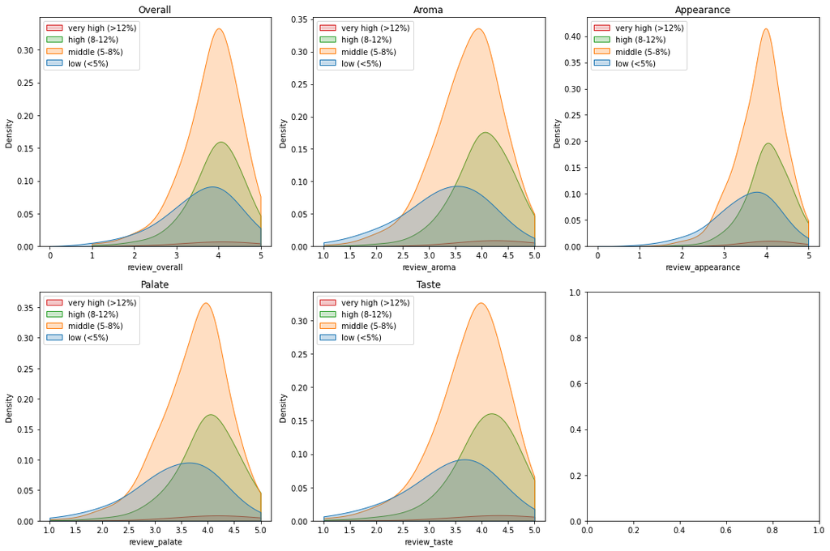

```python
fig, axs = plt.subplots(2,3, figsize=(15, 10))
atributes = ["review_overall", "review_aroma", "review_appearance", "review_palate", "review_taste"]
titles = ["Overall", "Aroma", "Appearance", "Palate", "Taste"]

for i in range(len(atributes)):
    ax = plt.subplot(2,3,i+1)
    sns.kdeplot(brew_df[atributes[i]], shade=True, color="r", bw_adjust = 7, cut=0, hue=brew_df['alcohol_level'])
    ax.legend(["very high (>12%)", "high (8-12%)", "middle (5-8%)", "low (<5%)"],loc=2)
    ax.set_title(titles[i])

plt.tight_layout()
plt.show()
```

En estos gráficos podemos observar como el porcentaje de alcohol parece no influenciar mucho en la nota ya que encontramos los picos en un lugar similar. No obstante, en palatividad y gusto parece que las cervezas con bajo porcentaje de alcohol tienen una mayor densidad en una puntuación inferior además de una mayor dispersión.

Para poder contrarestar estas observaciones vamos a estudiar unos violin plots donde expongamos los mismos gráficos y así poder ampliar el tamaño tanto de las cervezas de bajo como muy alto porcentaje de alcohol.

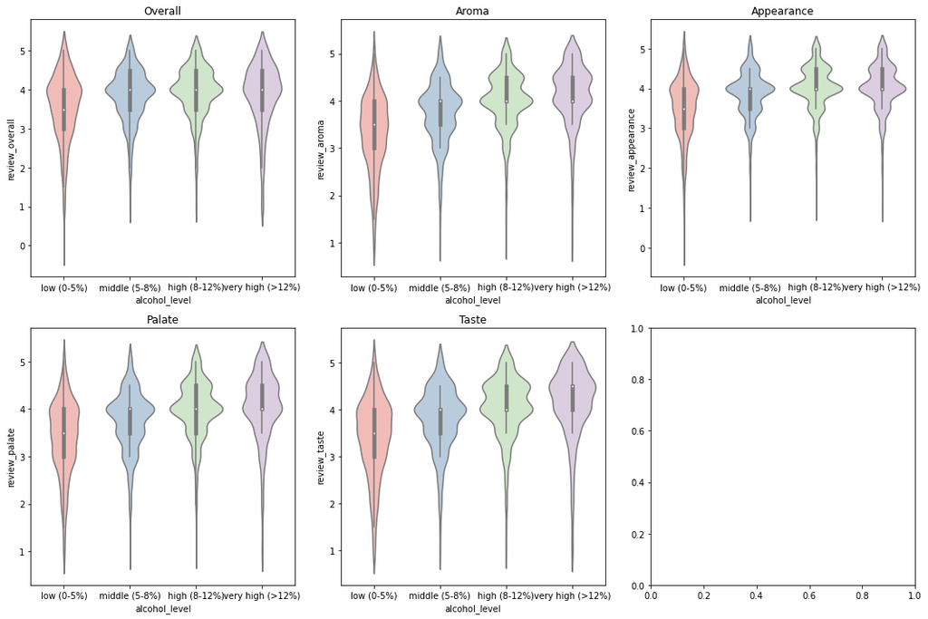

```python
fig, axs = plt.subplots(2,3, figsize=(15, 10))
for i in range(len(atributes)):
    ax = plt.subplot(2,3,i+1)
    sns.violinplot(data=brew_df, x="alcohol_level", y=atributes[i], bw=0.3, palette="Pastel1")
    ax.set_title(titles[i])

plt.tight_layout()
plt.show()
```

En estos violin plots se obtiene información más detacable, primero de todo vemos como las cervezas con bajo porcentaje de alcohol tienen una mayor dispersión que el resto.

Al evaluar la puntuación global, parece que todos los tipos de cerveza encuentran su máximo de densidad alrededor de un 4 de puntuación. En aroma, palatividad y gusto encontramos un comportamiento muy similar en el que se observa que las cervezas de baja graduación oscilan entre el 3 y el 4, mientras que el resto suben del 4 especialmente las de alta y muy alta graduación, siendo estas las que obtienen la mayor puntuación en aroma. En apariencia todas las graduaciones tienen un comportamiento muy similar, excepto las de baja graduación que tienen una puntuación ligeramente inferior al resto y más dispersa.

De todo esto podemos concluir que las cervezas con una menor graduación tienen una mayor dispersión además de tener unas puntuaciones más bajas en todos los aspectos. Las cervezas de graduación media, alta y muy alta son las que muestran menores dispersiones y mejores puntuaciones en todos los atributso destacando en gusto, palatividad y aroma. Encontrando en las de muy alto porcentaje de alcoho las cervezas valoradas con el mejor gusto.

### Relación entre las distintas puntuaciones

A continuación se va a estudiar si existe algún tipo de relación entre las distintas puntuaciones, es decir si una cerveza que tenga una alta puntuación en gusto también lo hará en aroma, para ello mostraremos las puntuaciones comparadas dos a dos.

*Nota:Por problemas con la capacidad de mi ordenador he tenido que optar por analizar exlcusivamente los primeros 10000 datos en los próximos gráficos porque el tiempo de procesado era excesivamente largo.*

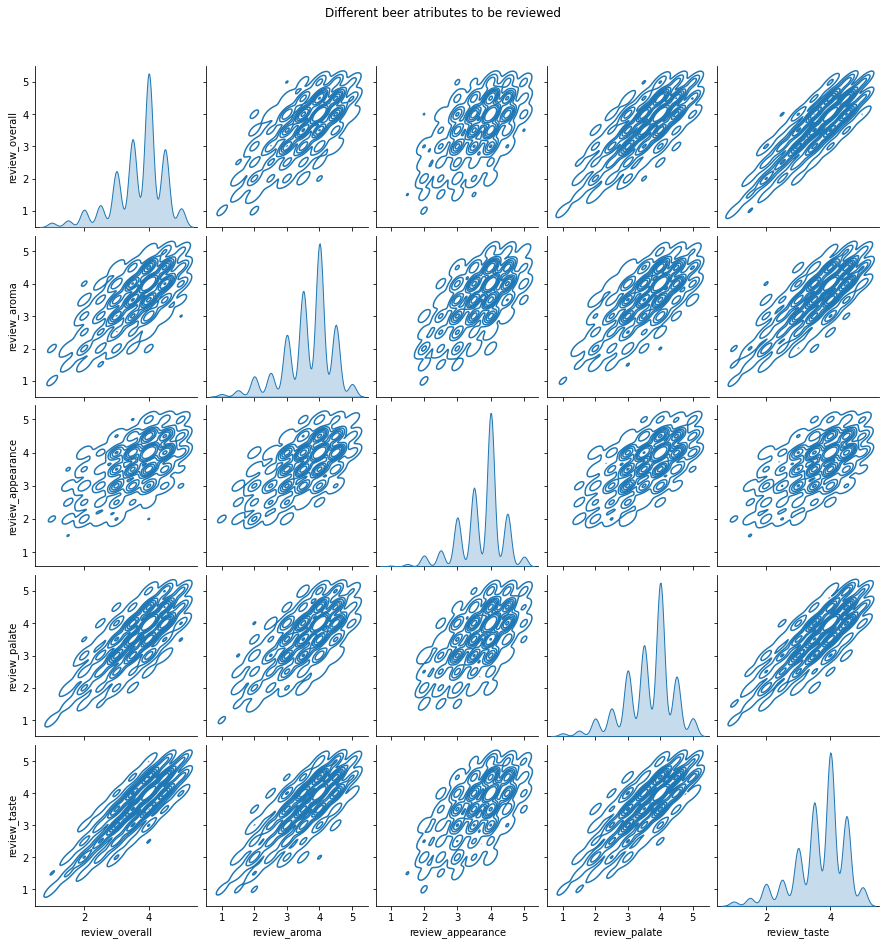

```python
df_sns = pd.DataFrame(brew_df, columns = ["review_overall", "review_aroma", "review_appearance", "review_palate", "review_taste"])

sns.pairplot(df_sns.head(10000), kind="kde")
plt.suptitle("Different beer atributes to be reviewed", y=1.05)
plt.show()
```

De estos gráficos si que podemos encontrar una correlación entre diferentes atributos. En los gráficos de densidad de kernel bivariables, cuanto más se acerque a una línea el área de datos podremos asumir que tenemos una mayor correlación entre las distintas variables. En ese aspecto podemos concluir que las variables con mayor correlación son review_overall con review_taste y review_taste con review_palate. Mientras que el atributo review_appearance no tiene una correlación clara con ningún otro atributo y review_aroma parece no tener una correlación clara con ningún atributo excepto con review_taste.

De este análisis podemos obtener diversas conclusiones. Analizaremos cada una de las correlaciones mencionadas anteriormente, estudiando cada uno de los atributos.

Por un lado, la puntuación global de la cerveza tiene una gran correlación con review_taste lo que parece evidente, pero es positivo encontrar que los resultados confirman nuestras hipótesis iniciales. Según esta correlación el atributo que mayor influencia tendrá en la nota final de la cerveza será el gusto de ésta. Por lo otro que vemos en estos gráficos podemos deducir que la palatividad y el aroma tienen una cierta influencia en la nota final y es la apariencia de la cerveza el atributo que tiene menor influencia.

En cuanto al atributo review_aroma podemos concluir que la única variable con la que muestra una correlación, y no muy alta, es con el gusto, con lo que podríamos decir que por lo general una cerveza con un buen aroma tenderá a tener un mejor gusto. No obstante, no se observa una gran correlación con la apariencia o la palatividad.

La apariencia de la cerveza resulta ser el atributo menos correlacionado con el resto de atributos, deduciendo que la puntuación en este atributo nos dará una mera idea de la puntuación en el resto de atributos, pero sin una gran fiabilidad.

La palatividad de la cerveza parece estar altamente correlacionada con el gusto de la cerveza, siendo una de las mayores correlaciones que encontramos entre estos atributos. Una cerveza con buena palatividad tendrá un buen gusto generalmente. Algo similar ocurre, pero en menor medida, con la puntuación global de la cerveza.

Finalmente en cuanto al gusto de la cerveza vemos que se encuentra altamente correlacionada con la puntuación global de la cerveza y, en menor medida, con la palatividad de la cerveza, por ello una cerveza con una buena puntuación global y en palatividad, muy probablemente tendrá un buen sabor.

### Estudio de las características de las 10 cervezas mejor puntuadas

Finalmente se va a estudiar que cualidades tienen las 10 cervezas con mejor puntuación. Para ello vamos a mostrar un spider chart de las 10 cervezas con sus atributos. Para este gráfico se ha tomado como referencia el código de [4] y se ha adaptado a las variables de este ejercicio.

El gráfico se ha escalado para que solo se muestre el range [3.5-5] ya que todos los resultados se encontraban en ese rango y mostrando el rango completo era más complicado apreciar las diferencias entre los distintos atributos.

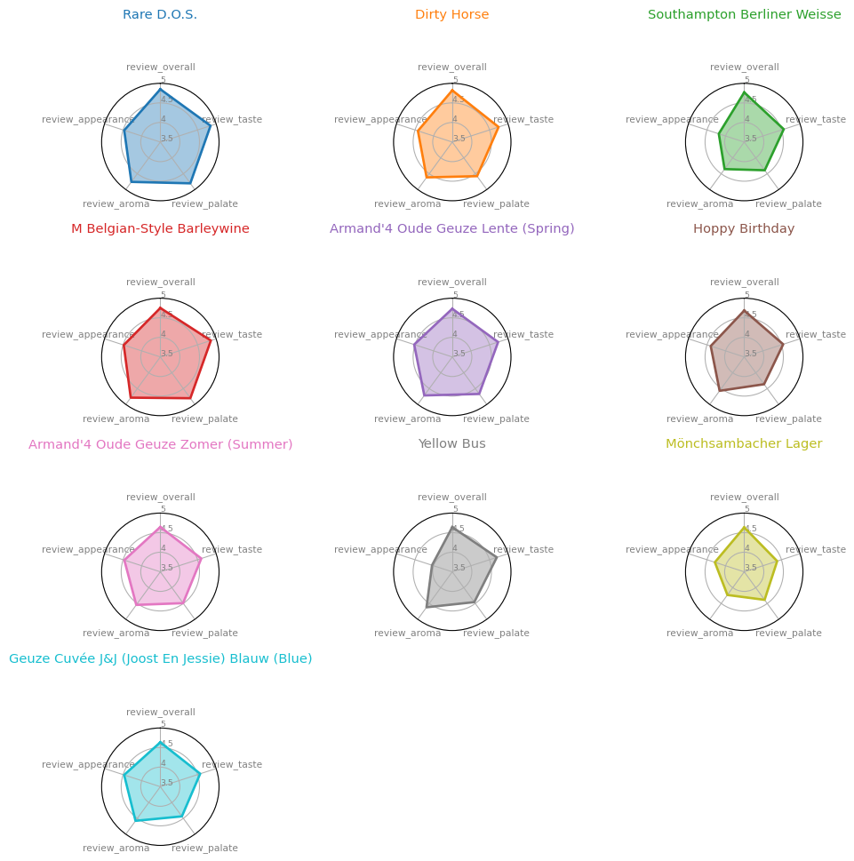

```python
def make_spider( row, title, color):

    # number of variable
    categories=list(brew_ten_df)[1:]
    N = len(categories)

    # What will be the angle of each axis in the plot? (we divide the plot / number of variable)
    angles = [n / float(N) * 2 * pi for n in range(N)]
    angles += angles[:1]

    # Initialise the spider plot
    ax = plt.subplot(4,3,row+1, polar=True, )
    plt.tight_layout()


    # If you want the first axis to be on top:
    ax.set_theta_offset(pi / 2)
    ax.set_theta_direction(-1)

    # Draw one axe per variable + add labels labels yet
    plt.xticks(angles[:-1], categories, color='grey', size=8)

    # Draw ylabels
    ax.set_rlabel_position(0)
    plt.yticks([3,3.5,4,4.5,5], ["3","3.5","4","4.5","5"], color="grey", size=7)
    plt.ylim(3.5,5)

    # Ind1
    values=brew_ten_df.loc[row].drop('beer_name').values.flatten().tolist()
    values += values[:1]
    ax.plot(angles, values, color=color, linewidth=2, linestyle='solid')
    ax.fill(angles, values, color=color, alpha=0.4)

    # Add a title
    plt.title(title, size=11, color=color, y=1.5)


# initialize the figure
my_dpi=96
plt.figure(figsize=(1000/my_dpi, 1000/my_dpi), dpi=my_dpi)

# Create a color palette:
my_palette = plt.cm.get_cmap("tab10", len(brew_ten_df.index))

# Loop to plot
for row in range(0, len(brew_ten_df.index)):
    make_spider( row=row, title=brew_ten_df['beer_name'][row], color=my_palette(row))
```

Si quisieramos probar una cerveza para alguien de quien no conocemos sus gustos le podríamos recomendar la Armand'4 Oude Geuze Lente o Zomer (sus variantes primavera y verano) al tratarse de una cerveza muy equilibrada en todos los atributos. No obstante, si lo que buscasemos fuese la cerveza con el mejor sabor de estas 10, nos quedaríamos con la M Belgian-Style Barleywine aunque la Rare D.O.S. también tiene una muy buena puntuación.

# Bibliografía

[1] Caihuelas Quiles, R., & Minguillón Alfonso, J. (2021). Proceso de minería de datos (PID_00284574). Fundació Universitat Oberta de Catalunya (FUOC).

[2] Gironés, J. (2021). Caso de estudio (PID_00284576). Fundació Universitat Oberta de Catalunya (FUOC).

[3] What is Unix time? (s/f). Narrative.io. Recuperado el 22 de octubre de 2021, de https://kb.narrative.io/what-is-unix-time

[4] Holtz, Y. (s/f). Use faceting for Radar chart. Python-graph-gallery.com. Recuperado el 22 de octubre de 2021, de https://www.python-graph-gallery.com/392-use-faceting-for-radar-chart